# Gam model: stillbirth

$d = \frac{log(OR)}{1.81}$

```r
#table to show OR, confidence interval and Cohen's d
  OR <- exp(coef(m_SB_bam2))
  beta <- coef(m_SB_bam2)
  Vb <- vcov(m_SB_bam2, unconditional = TRUE)
  se <- sqrt(diag(Vb))
  lci <- exp(beta-1.96*se)
  uci <- exp(beta+1.96*se)
  d <- abs(beta)/1.81
  my.ci <- data.frame(cbind(OR, lci, uci, d))
  round(head(my.ci, 12), 2)
```

```
##                                                        OR  lci  uci    d
## (Intercept)                                          0.00 0.00 0.00 3.66
## birth_Y_M_num                                        1.00 1.00 1.00 0.00
## mean_ssep2                                           0.99 0.99 1.00 0.00
## Urban3                                               1.04 0.96 1.12 0.02
## LanguageFrench                                       1.08 0.99 1.18 0.04
## LanguageItalian                                      0.98 0.80 1.20 0.01
## mother_nationality_cat2Africa                        1.26 1.05 1.51 0.13
## mother_nationality_cat2Asia                          0.96 0.79 1.18 0.02
## mother_nationality_cat2Europe                        1.03 0.95 1.12 0.02
## mother_nationality_cat2Northern America              0.71 0.40 1.23 0.19
## mother_nationality_cat2Oceania                       0.84 0.20 3.45 0.10
## mother_nationality_cat2Southern and Central America  0.91 0.70 1.18 0.05
```

Time variables (birth_Y_M_num) and mean ssep variable were put as linear terms, because the model including them as smoothed terms showed that the relationship between these and stillbirth was linear.

#Adding BW –> discussing this.

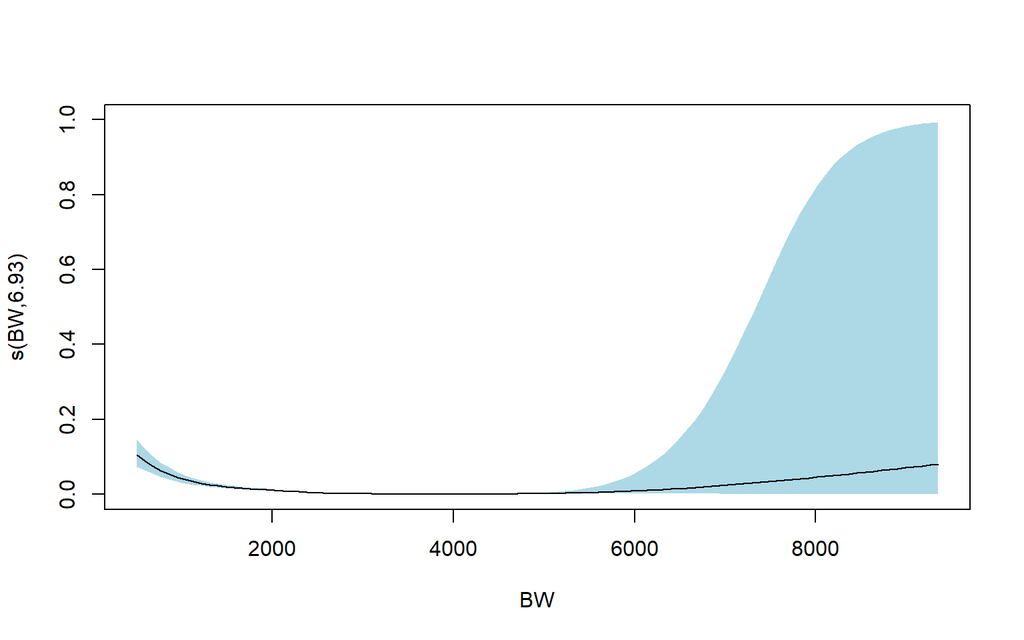

```r
 m_SB_bam3 = update(m_SB_bam2, . ~ . + s(BW))
plot(m_SB_bam3, trans = plogis, select=4, ylim=c(0, 1), shift = coef(m_SB_bam3)[1], shade = TRUE, shade.col = "lightblue") #BW with whole CI
```

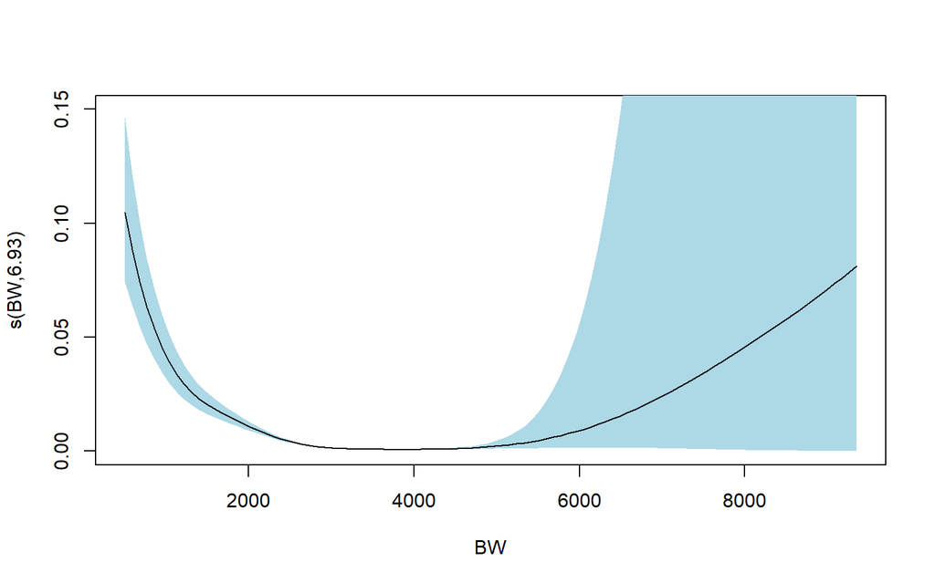

```r
  plot(m_SB_bam3, trans = plogis, select=4, ylim=c(0, 0.15), shift = coef(m_SB_bam3)[1], shade = TRUE, shade.col = "lightblue") #BW
```

```r
  concurvity(m_SB_bam3)
```

```
##               para s(GA_weeks) s(mat_age)     s(month)     s(BW)
## worst    0.9829455   0.8787415 0.05483844 0.0045794820 0.8787530
## observed 0.9829455   0.4617487 0.01746103 0.0006330721 0.5160650
## estimate 0.9829455   0.4140313 0.03533273 0.0034246658 0.3330819
```

When we add birthweight, there is too much correlation betwwen gestational age and birthweight (concurvity shows 0.88 which is to close to 1): it is not a good idea to include BW in the model. But we can have a look at the smoothed curve for stillbirth depending on birthweight: it has a clear U shaped, with high stillbirth risk (2-11%) for very low birthweight babies (<2kg), and moderately high stillbirth risk (5-8%) for very high birthweight babies (>8kg).

## 2008-2010

```r
m_SB_bam_2009_2<-bam(stillbirth~s(GA_weeks)+ s(mat_age, k=7) + birth_Y_M_num + mean_ssep2 + Urban3 + Language + mother_nationality_cat2,family="binomial", data=bevn_eco_in6_2008_10)
summary(m_SB_bam_2009_2)
```

```
##
## Family: binomial
## Link function: logit
##
## Formula:
## stillbirth ~ s(GA_weeks) + s(mat_age, k = 7) + birth_Y_M_num +
##     mean_ssep2 + Urban3 + Language + mother_nationality_cat2
##
## Parametric coefficients:
##                                                       Estimate Std. Error z value Pr(>|z|)
## (Intercept)                                          -6.408576   0.339228 -18.892   <2e-16 ***
## birth_Y_M_num                                        -0.003879   0.004052  -0.957   0.3385
## mean_ssep2                                           -0.007007   0.005230  -1.340   0.1803
## Urban3                                                0.174863   0.086722   2.016   0.0438 *
## LanguageFrench                                        0.033909   0.100425   0.338   0.7356
## LanguageItalian                                       0.043843   0.208702   0.210   0.8336
## mother_nationality_cat2Africa                        -0.307892   0.262929  -1.171   0.2416
## mother_nationality_cat2Asia                          -0.623295   0.292794  -2.129   0.0333 *
## mother_nationality_cat2Europe                         0.065891   0.093736   0.703   0.4821
## mother_nationality_cat2Northern America              -0.832096   0.740930  -1.123   0.2614
## mother_nationality_cat2Oceania                       -8.197695  52.128818  -0.157   0.8750
## mother_nationality_cat2Southern and Central America  -0.318662   0.314474  -1.013   0.3109
## ---
## Signif. codes:  0 '***' 0.001 '**' 0.01 '*' 0.05 '.' 0.1 ' ' 1
##
## Approximate significance of smooth terms:
##               edf Ref.df  Chi.sq p-value
## s(GA_weeks) 5.937  6.945 3434.41  <2e-16 ***
## s(mat_age)  2.034  2.551    3.07   0.301
## ---
## Signif. codes:  0 '***' 0.001 '**' 0.01 '*' 0.05 '.' 0.1 ' ' 1
##
## R-sq.(adj) =  0.149   Deviance explained = 32.5%
## fREML = 3.1243e+05  Scale est. = 1         n = 220464
```

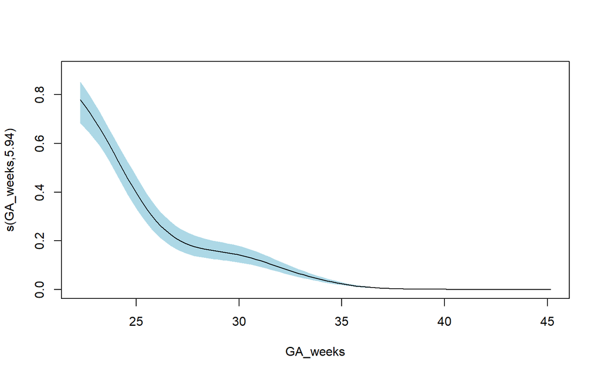

```r
   plot(m_SB_bam_2009_2, trans = plogis, select=1, ylim=c(0, 0.9) ,shift = coef(m_SB_bam_2009_2)[1], shade = TRUE, shade.col = "lightblue") #GA
```

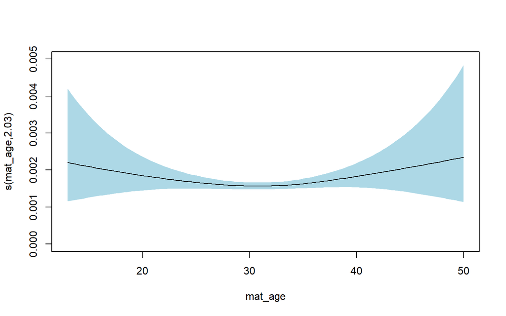

```r
  plot(m_SB_bam_2009_2, trans = plogis, select=2, ylim=c(0, 0.005), shift = coef(m_SB_bam_2009_2)[1], shade = TRUE, shade.col = "lightblue") #mat age
```

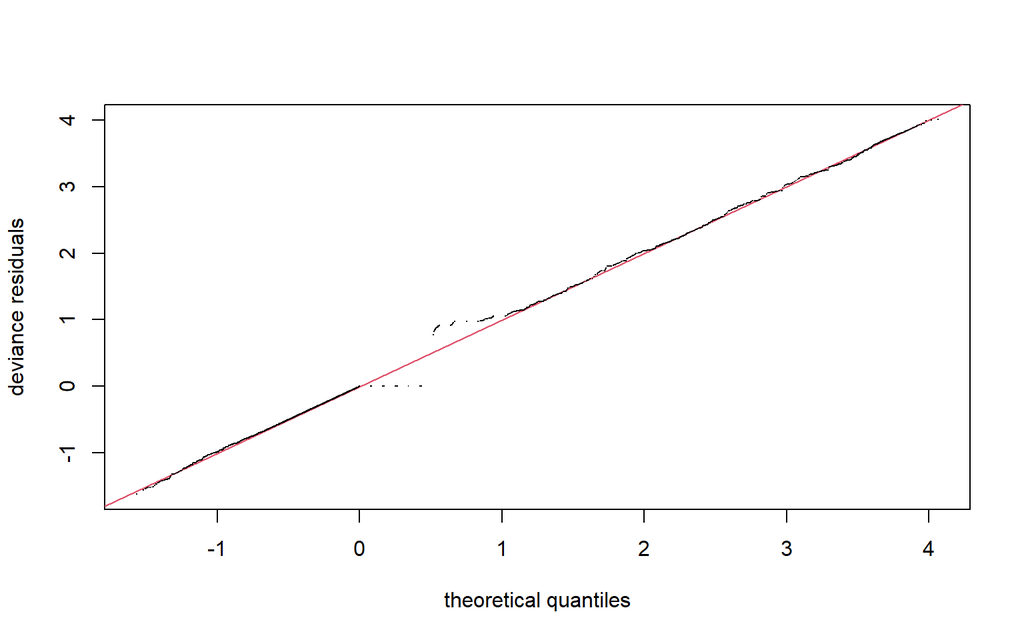

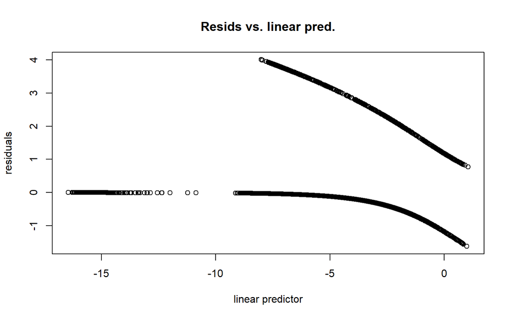

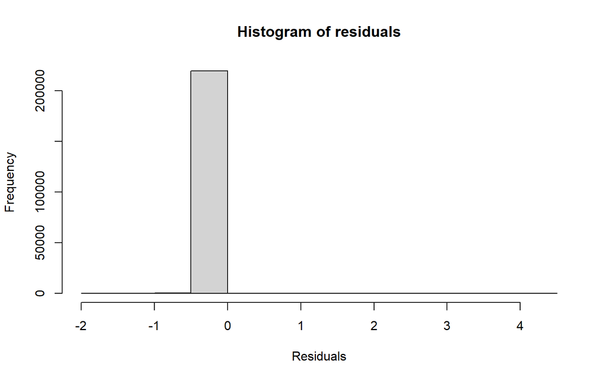

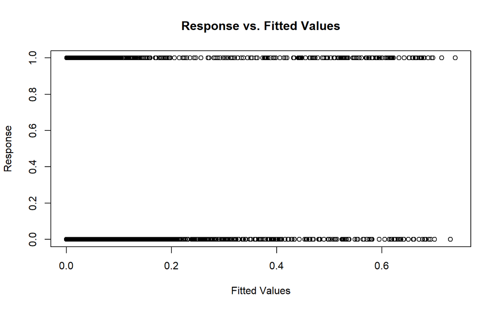

```
##
## Method: fREML   Optimizer: perf newton
## full convergence after 4 iterations.
## Gradient range [-2.625943e-09,9.547061e-06]
## (score 312428.8 & scale 1).
## Hessian positive definite, eigenvalue range [0.4109801,2.052203].
## Model rank =  27 / 27
##
## Basis dimension (k) checking results. Low p-value (k-index<1) may
## indicate that k is too low, especially if edf is close to k'.
##
##               k'  edf k-index p-value
## s(GA_weeks) 9.00 5.94    0.83    0.01 **
## s(mat_age)  6.00 2.03    0.89    0.71
## ---
## Signif. codes:  0 '***' 0.001 '**' 0.01 '*' 0.05 '.' 0.1 ' ' 1
```

```r
  gam.check(m_SB_bam_2009_2)
```

```r
  concurvity(m_SB_bam_2009_2)
```

```
##               para s(GA_weeks)  s(mat_age)
## worst    0.9840551 0.010398851 0.061160016
## observed 0.9840551 0.005436465 0.005779778
## estimate 0.9840551 0.006773190 0.035691703
```

```r
  OR <- exp(coef(m_SB_bam_2009_2))
  beta <- coef(m_SB_bam_2009_2)
  Vb <- vcov(m_SB_bam_2009_2, unconditional = TRUE)
  se <- sqrt(diag(Vb))
  lci <- exp(beta-1.96*se)
  uci <- exp(beta+1.96*se)
  d <- abs(beta)/1.81
  my.ci <- data.frame(cbind(OR, lci, uci, d))
  round(head(my.ci, 12), 2)
```

```
##                                                        OR  lci          uci    d
## (Intercept)                                          0.00 0.00 0.000000e+00 3.54
## birth_Y_M_num                                        1.00 0.99 1.000000e+00 0.00
## mean_ssep2                                           0.99 0.98 1.000000e+00 0.00
## Urban3                                               1.19 1.00 1.410000e+00 0.10
## LanguageFrench                                       1.03 0.85 1.260000e+00 0.02
## LanguageItalian                                      1.04 0.69 1.570000e+00 0.02
## mother_nationality_cat2Africa                        0.73 0.44 1.230000e+00 0.17
## mother_nationality_cat2Asia                          0.54 0.30 9.500000e-01 0.34
## mother_nationality_cat2Europe                        1.07 0.89 1.280000e+00 0.04
## mother_nationality_cat2Northern America              0.44 0.10 1.860000e+00 0.46
## mother_nationality_cat2Oceania                       0.00 0.00 6.497288e+40 4.53
## mother_nationality_cat2Southern and Central America  0.73 0.39 1.350000e+00 0.18
```

As for the previous model (including all timing 2007-2020), we kept time(birth_Y_M_num) and mean_ssep2 as linear terms.

## 2017-2020

```r
m_SB_bam_covid_2 <-bam(stillbirth~s(GA_weeks)+ mat_age + birth_Y_M_num +  mean_ssep2 + Urban3 + Language + mother_nationality_cat2,family="binomial", data=bevn_eco_in6_2017_20)
summary(m_SB_bam_covid_2)
```

```
##
## Family: binomial
## Link function: logit
##
## Formula:
## stillbirth ~ s(GA_weeks) + mat_age + birth_Y_M_num + mean_ssep2 +
##     Urban3 + Language + mother_nationality_cat2
##
## Parametric coefficients:
##                                                       Estimate Std. Error z value Pr(>|z|)
## (Intercept)                                          -6.794848   0.471639 -14.407  < 2e-16 ***
## mat_age                                               0.007085   0.006871   1.031 0.302447
## birth_Y_M_num                                        -0.002495   0.002496  -1.000 0.317501
## mean_ssep2                                           -0.001567   0.004273  -0.367 0.713770
## Urban3                                               -0.121121   0.071465  -1.695 0.090107 .
## LanguageFrench                                        0.168834   0.078861   2.141 0.032282 *
## LanguageItalian                                      -0.244986   0.230082  -1.065 0.286978
## mother_nationality_cat2Africa                         0.552349   0.149243   3.701 0.000215 ***
## mother_nationality_cat2Asia                           0.192085   0.167090   1.150 0.250312
## mother_nationality_cat2Europe                         0.022826   0.078368   0.291 0.770843
## mother_nationality_cat2Northern America               0.274686   0.439897   0.624 0.532344
## mother_nationality_cat2Oceania                       -8.133629  46.445173  -0.175 0.860983
## mother_nationality_cat2Southern and Central America   0.044082   0.242353   0.182 0.855667
## ---
## Signif. codes:  0 '***' 0.001 '**' 0.01 '*' 0.05 '.' 0.1 ' ' 1
##
## Approximate significance of smooth terms:
##               edf Ref.df Chi.sq p-value
## s(GA_weeks) 7.421  8.111   4940  <2e-16 ***
## ---
## Signif. codes:  0 '***' 0.001 '**' 0.01 '*' 0.05 '.' 0.1 ' ' 1
##
## R-sq.(adj) =  0.127   Deviance explained = 33.1%
## fREML = 4.7434e+05  Scale est. = 1         n = 333721
```

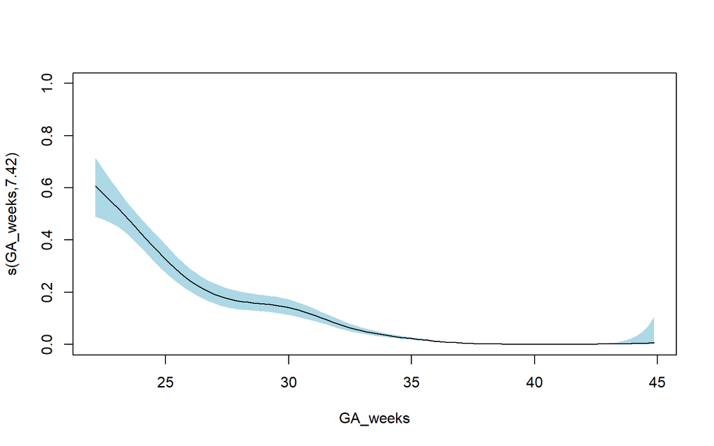

```r
 plot(m_SB_bam_covid_2, trans = plogis, select=1, ylim=c(0, 1) ,shift = coef(m_SB_bam_covid_2)[1], shade = TRUE, shade.col = "lightblue") #GA
```

```r
  OR <- exp(coef(m_SB_bam_covid_2))
  beta <- coef(m_SB_bam_covid_2)
  Vb <- vcov(m_SB_bam_covid_2, unconditional = TRUE)
  se <- sqrt(diag(Vb))
  lci <- exp(beta-1.96*se)
  uci <- exp(beta+1.96*se)
  d <- abs(beta)/1.81
  my.ci <- data.frame(cbind(OR, lci, uci, d))
  round(head(my.ci, 13), 2)
```

```
##                                                        OR  lci          uci    d
## (Intercept)                                          0.00 0.00 0.000000e+00 3.75
## mat_age                                              1.01 0.99 1.020000e+00 0.00
## birth_Y_M_num                                        1.00 0.99 1.000000e+00 0.00
## mean_ssep2                                           1.00 0.99 1.010000e+00 0.00
## Urban3                                               0.89 0.77 1.020000e+00 0.07
## LanguageFrench                                       1.18 1.01 1.380000e+00 0.09
## LanguageItalian                                      0.78 0.50 1.230000e+00 0.14
## mother_nationality_cat2Africa                        1.74 1.30 2.330000e+00 0.31
## mother_nationality_cat2Asia                          1.21 0.87 1.680000e+00 0.11
## mother_nationality_cat2Europe                        1.02 0.88 1.190000e+00 0.01
## mother_nationality_cat2Northern America              1.32 0.56 3.120000e+00 0.15
## mother_nationality_cat2Oceania                       0.00 0.00 1.005865e+36 4.49
## mother_nationality_cat2Southern and Central America  1.05 0.65 1.680000e+00 0.02
```

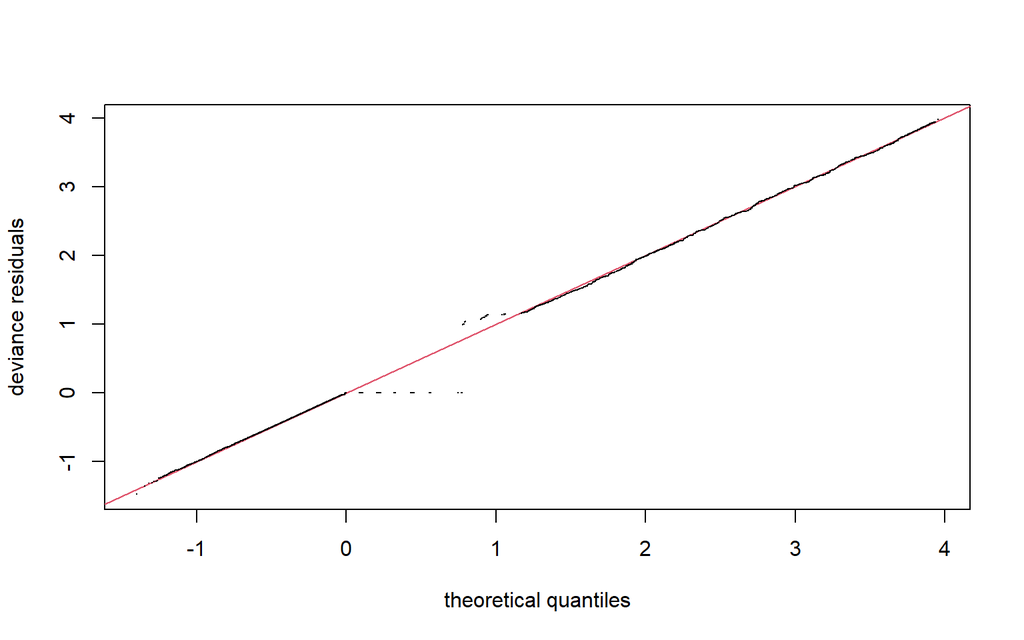

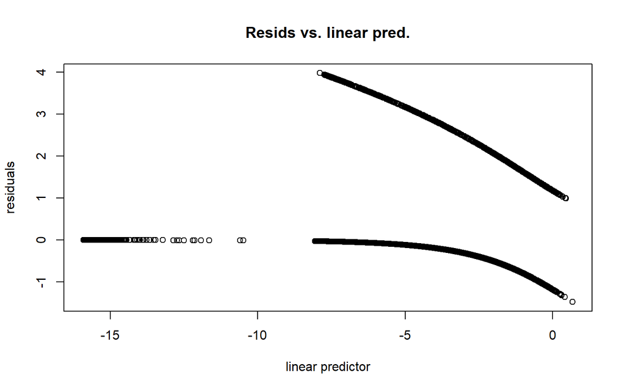

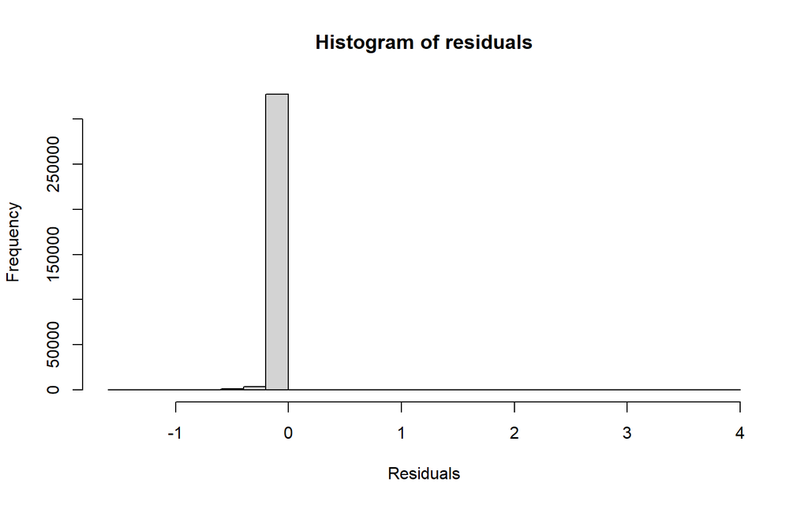

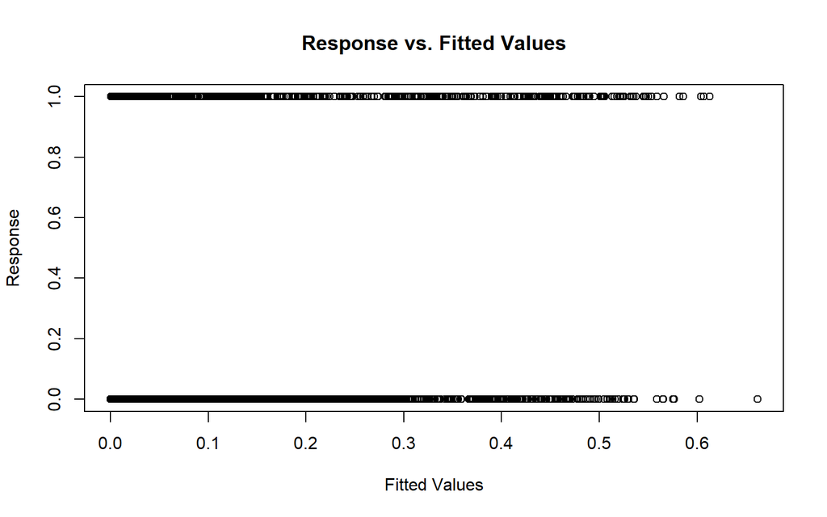

```
##
## Method: fREML   Optimizer: perf newton
## full convergence after 5 iterations.
## Gradient range [0.001286939,0.001286939]
## (score 474338.6 & scale 1).
## Hessian positive definite, eigenvalue range [2.180729,2.180729].
## Model rank =  22 / 22
##
## Basis dimension (k) checking results. Low p-value (k-index<1) may
## indicate that k is too low, especially if edf is close to k'.
##
##               k'  edf k-index p-value
## s(GA_weeks) 9.00 7.42    0.87  <2e-16 ***
## ---
## Signif. codes:  0 '***' 0.001 '**' 0.01 '*' 0.05 '.' 0.1 ' ' 1
```

```r
 gam.check(m_SB_bam_covid_2)
```

```r
 concurvity(m_SB_bam_2009_2)
```

```
##               para s(GA_weeks)  s(mat_age)
## worst    0.9840551 0.010398851 0.061160016
## observed 0.9840551 0.005436465 0.005779778
## estimate 0.9840551 0.006773190 0.035691703
```